# Une analyse textuelle des synopsis de ‘Rendez-vous avec X’

Laurent Callot

# Les mots des titres de Monsieur X.

Le code utilisé pour créer les visualisations dans ce document est disponible dans son repo/

```r
library(tm)
library('magrittr')
library("SnowballC")
library('wordcloud')
library('RColorBrewer')
source('libs.R')
```

## Les titres

Deux grandes étapes:

1. Construction d’un corpus des titres, nettoyé autant que possible.
2. Création d’un nuage de mots des titres.

La création du corpus est présenté en détail plus bas dans le cas des synopsis.

Nuage de mots des titres.

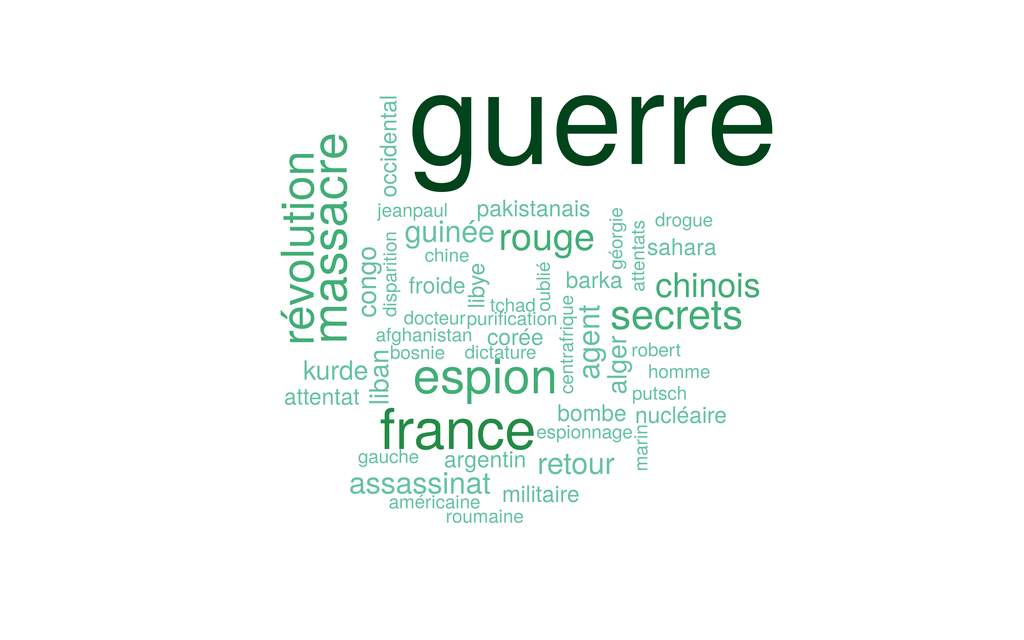

## Recuperation des épisodes.

Un [site non-officiel](http://rendezvousavecmrx.free.fr) de rendez-vous avec X fournit une liste des épisodes avec synopsis pour les items 156 à 761.

Une boucle sur les 606 épisodes pour lesquels un synopsis existe permet de récupérer pour chaque épisodes:

1. Une chaîne de caractères contenant la ou les dates de diffusion de l’épisode.
2. Le titre de l’épisode.
3. Le synopsis. Ces données sont stocké dans une liste que est sauvé dans *rawdata_rdvX*.

```r
GetRDVXSynop()
```

## Les synopsis.

J’utilise le packages *tm* et en complément *SnowballC* pour extraire le texte des synopsis, le transformer en corpus et nettoyer. Quelques librairies supplémentaires seront chargé en route.

```r
# create the corpus for the synopsis
#raw_data[,3] <- gsub('\'',' ',raw_data[,3] )
vsource_synop <- VectorSource(raw_data[,3])
corp_synop <- Corpus(vsource_synop)
corp_synop <- clean_corpus(corp_synop,rm_common = 3500)
```

On commence par chercher les données brut. **clean_corpus** nettoie et formate le corpus. Étapes du nettoyage du corpus:

1. Tout en minuscule.
2. Retirer les nombres.
3. Stemming et dé-stemming en utilisant la liste des 10000 mots les plus fréquent comme dictionnaire de complétion.
4. Retirer la ponctuation.
5. Retirer les stopwords français avec la liste de *tm* + 2 autres listes + une courte liste fait main.
6. Retirer les 3500 mots les plus commun du français.

> *stemCompletion* ne fonctionne pas avec le corpus des synopsis.

Nous pouvons maintenant construire les nuage de mots en utilisant le packages *wordcloud*, d’abord avec les synopsis:

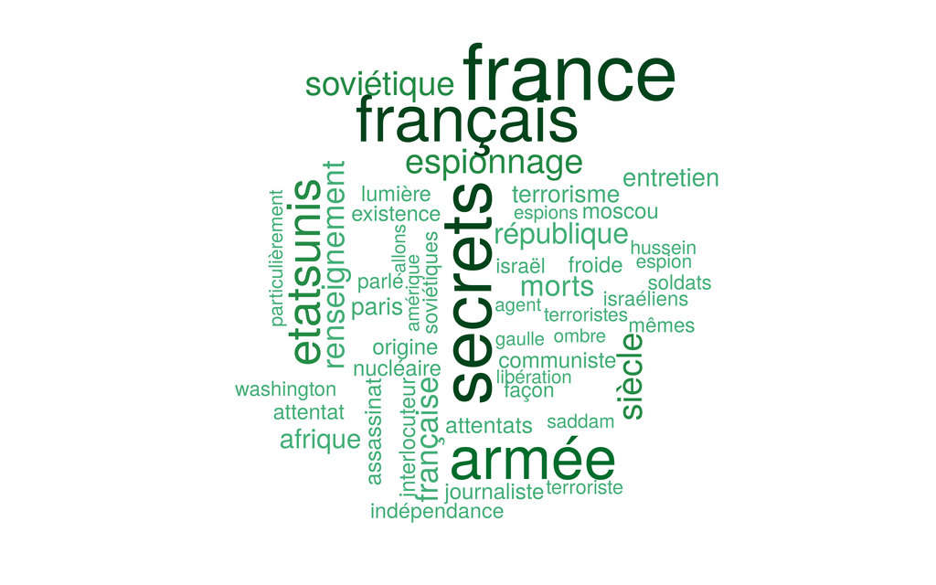

```r
wcloud(corp_synop,wlength = 5,maxw = 50,scale=c(8,.3))
```

## Correlations

### Correlations dans les titres

```r
dtm <- DocumentTermMatrix(corp_title, control = list(wordLengths =c(5,Inf)))

findNassocs <- function(dtm,x,nassoc=3){
  mass <- matrix(NA,ncol=length(x),nrow=nassoc)
  y <- findAssocs(dtm,x,corlimit=0.01)
  if(is.list(y))for(i in 1:length(y)){mass[,i] <- names(y[[i]][1:nassoc]) }
  if(!is.list(y)) mass[,1] <- rownames(y)[1:nassoc]

  colnames(mass) <- x
  return(mass)
}

tb <- findNassocs(dtm, c("guerre",'secrets','rouge','espion','assassinat'), nassoc = 5)
kable(tb)
```

| guerre | secrets | rouge | espion | assassinat |
| --- | --- | --- | --- | --- |
| bactériologique | israëlpalestine | fraction | ariane | kadhafi |
| corée | britaniques | khmers | hernu | paolo |
| intox | cambodge | armée | krassilnikov | paris |
| froide | francoaméricaine | cambodge | maîtres | pasolini |
| civile | indochine | japonaise | parfait | renaud |

| putsch | révolution | armée | massacre | sahara |
| --- | --- | --- | --- | --- |
| mercenaires | roumaine | fraction | melouza | implanté |
| equatoriale | culturelle | joseph | beach | alger |
| guinée | orange | résistance | beslan | qaïda |
| brésil | cubaine | seigneur | émeutes | occidental |
| avril | morgan | rouge | harkis | guerre |

| chinois | alger | france | guinée | congo |
| --- | --- | --- | --- | --- |
| culturelle | bataille | otages | equatoriale | démocratique |
| ambassade | putsh | allemands | mercenaires | république |
| belgrade | sahara | pilotes | putsch | brazzaville |
| leung | guerre | bosnie | bissau | guerre |
| maîtres | NA | espionnage | europe | NA |

### Correlations dans les synopsis.

| terrorisme | attentats | communiste | espion | assassinat |
| --- | --- | --- | --- | --- |
| baader | revendiqués | varsovie | taupe | avortée |
| affectés | animé | assorti | démasqué | fermons |
| agresser | artisanal | astreints | aéronautique | flingué |
| atomiquearrêtons | blessées | bratislava | billion | focaliser |
| aucunement | champsélysées | caudines | briller | formulé |

| putsch | armée | massacre | nucléaire | république |
| --- | --- | --- | --- | --- |
| aisance | andrei | indigènes | atome | karadzic |
| anecdotes | andreïevitch | bouchareb | prolifération | sarajevo |
| antenne | brisés | consacrait | folamour | serbe |
| apparitions | commandées | émeuve | apprentis | serbes |
| applaudissements | décapitation | fêtait | appuiera | accablés |

| chine | afrique | france | israël | gaulle |
| --- | --- | --- | --- | --- |
| pékin | colonies | bailleur | hébreu | agacer |
| affrontant | eyadéma | légitimité | israéliens | blocs |
| bloquer | africaines | repoussoir | israélienne | convaincante |
| chenille | autorisaient | abritons | palestiniens | franche |
| colonne | bilatéraux | amourhaine | benyamin | idéologies |